# Introducing The turnR Package

Dusty Turner

2019-05-29

## Inspiration

At the [2019 New York R Conference](https://www.rstats.nyc/), [Emily Robinson](https://twitter.com/robinson_es) gave a great talk called [“Everything You Wanted to Know About Making R Packages but Were Afraid to Ask”](https://www.rstats.nyc/2019/nyr/) (*Note: This link will be live once the video is published*). I dabbled with creating a [package](https://github.com/dusty-turner/puertoRicoR) before, but her talk made creating a package so much more tangible (and scale-able).

Armed with her inspiration and her brother’s sage advice (below):

> When you’ve written the same code 3 times, write a function  
> When you’ve given the same in-person advice 3 times, write a blog post

> — David Robinson (@drob) [November 9, 2017](https://twitter.com/drob/status/928447584712253440?ref_src=twsrc%5Etfw)

I now have all the encouragement I needed to give this a hack.

I will spare all the frustrating details, but the appropriately named book, [“R Packages”](https://r-pkgs.org/index.html) by Hadley Wickham and [Jenny Bryan](https://twitter.com/JennyBryan) tell you all you need to know to create your own package. [Chapter 2](https://r-pkgs.org/whole-game.html) is the one-stop-shop I used to get my package off the ground. There is, of course, more to do to get this fully developed.

## turnR

To download the `turnR` package, run the uncommented code below. Then call the package.

```r
# devtools::install_github("dusty-turner/turnR", force = TRUE)
library(turnR)
```

### Available Functions

To get the package off the ground, I created a simple function inspired by my 4 year old daughter.

```r
mycat(CatName = "Garfield")
```

```
## Your Cat's Name is Garfield
##    /\_/\
##   ( o.o )
##    > ^ <
##   (     )
##    ^   ^
##    _____
```

I also find myself making some of the same adjustments over and over again to my ggplots. In particular, I like to center the title and remove the legend for certain plots. Here is a look.

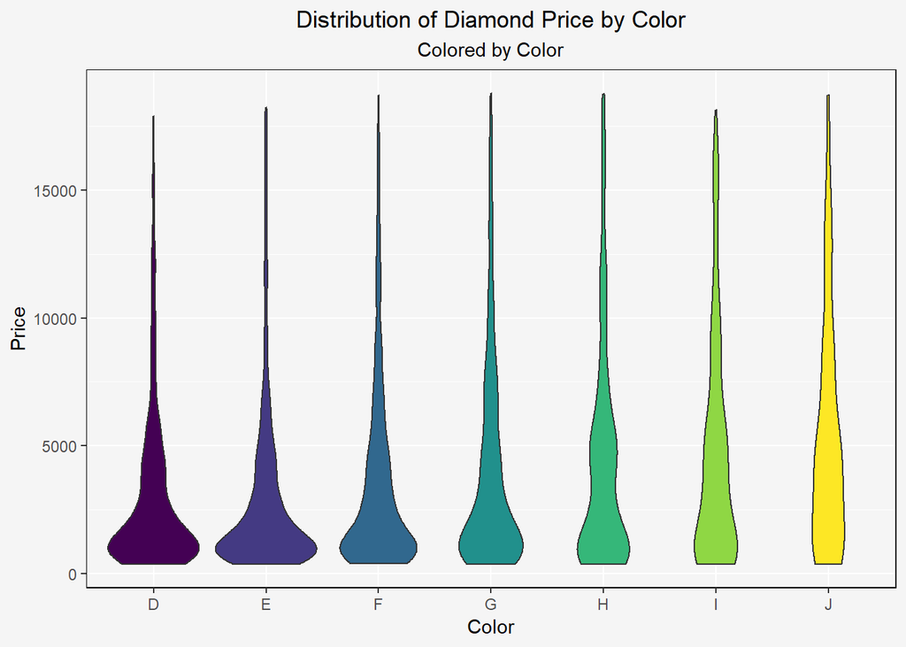

```r
library(tidyverse)
set.seed(256)
data("diamonds")

diamonds = diamonds %>%
  sample_frac(.1)

diamonds %>%
  ggplot(aes(x=color,y=price,fill = color)) +
  geom_violin() +
  labs(x="Color",y="Price",title="Distribution of Diamond Price by Color", subtitle = "Colored by Color") +
  theme_turnR()
```

Sometimes, when my ‘x’ axis is a factor, the labels run over. This fixes that issue.

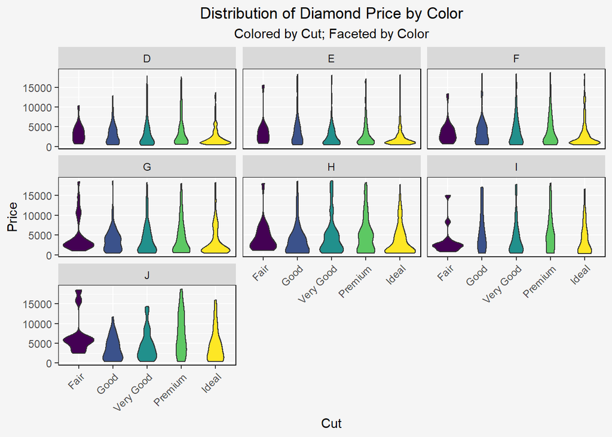

```r
diamonds %>%
  ggplot(aes(x=cut,y=price,fill = cut)) +
  geom_violin() +
  labs(x="Cut",y="Price",title="Distribution of Diamond Price by Color", subtitle = "Colored by Cut; Faceted by Color") +
  theme_turnR_f() +
  facet_wrap(~color)
```

Lastly, as an alternative to `t.test`, I often run a randomization test. It gets frustrating finding my old code for this, so the `turnR` package to the rescue.

This test returns the probability that each null hypothesis is true along with the difference in means of each samples. It will also return all data under index 1: [1] (not shown).

```r
x=rnorm(100,5,2)
y=rnorm(100,5.1,1)
randtest(x=x,y=y,fun = mean, reps = 1000)[2]
```

```
## [[1]]
##    p.x.less.than.y p.x.greater.than.y    two.sided.p.x=y
##              0.850              0.150              0.306
```

```r
randtest(x=x,y=y,fun = mean, reps = 1000)[3]
```

```
## [[1]]
## [1] 0.2445667
```

And of course, it always helps to visualize the difference.

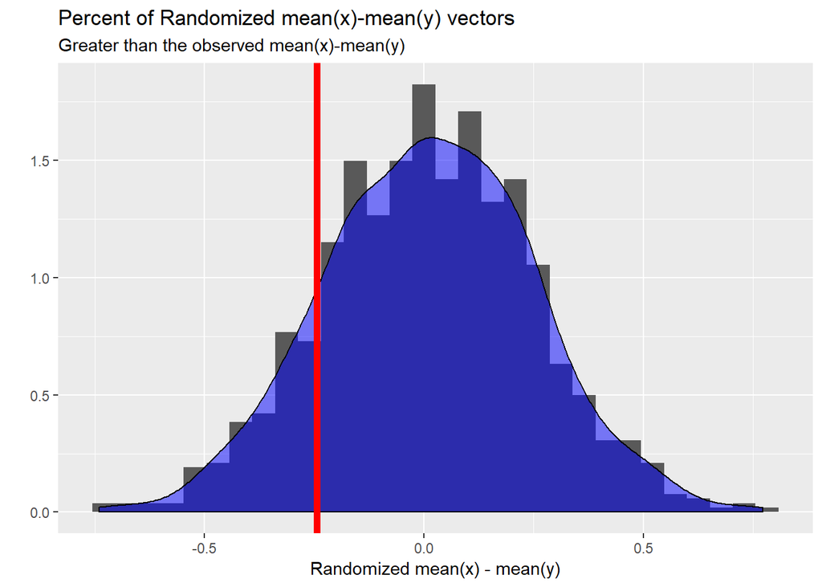

```r
randtestviz(x=x,y=y,fun=mean,reps=1000)
```

I expect more to follow in the future!